# NICU Density

Amanda Gassett

2024-04-08

Questions:  
1) Is this really the raw NICU data? It’s labeled clean?  
2) Facility-specific changes from year to year  
- Data missing for 1996  
- Different level categories for 2011 and 2023  
- Name changes, branch locations  
3) Thinking through levels of the data  
- NICU Addresses: point  
- Outcome: county?  
- Distance to NICU: Block, bg, or tract centroid to address? (Opiod used tract)  
– Population weighting by women of childbearing age?  
– Mean or median distance? - Race/Eth  
- Care deserts by county or tract?  
4) Outcome data?  
5) SAP and/or grant proposal? Which data sources have already been identified?

```r
all_nicu_geo <- read.csv("H:/Health Analysis/Casey_NICU/nicu_locations.csv")
table(all_nicu_geo[,c("level","year")])
```

```
##       year
## level  1996 2011 2023
##   II      0    0  560
##   IIA     0   28    0
##   IIB     0  128    0
##   III     0    2  709
##   IIIA    0  165    0
##   IIIB    0  530    0
##   IIIC    0  130    0
##   IV      0    0  127
```

```r
all_nicu_geo[grep("ALBANY",all_nicu_geo$name),]
```

```
##         X                  name beds      lat       lon num_neonats
## 520   520 ALBANY MEDICAL CENTER   50 42.65317 -73.77610           6
## 1442 1442 ALBANY MEDICAL CENTER   50 42.65408 -73.77596           9
## 1858 1858 ALBANY MEDICAL CENTER   60 42.65408 -73.77596          NA
##                  type level year
## 520              <NA>  <NA> 1996
## 1442             <NA>  IIIC 2011
## 1858 Academic Program    IV 2023
```

```r
all_nicu_geo[grep("MAYO",all_nicu_geo$name),]
```

```
##         X                                name beds      lat        lon
## 449   449               MAYO CLINIC ROCHESTER   30 44.02267  -92.46675
## 1319 1319              MAYO CLINIC ST. MARY'S   30 44.02087  -92.48159
## 1811 1811 FRANCISCAN SKEMP MAYO HEALTH SYSTEM   15 43.80436  -91.24271
## 2280 2280                  HENRY MAYO NEWHALL   11 34.39848 -118.55327
## 2468 2468            MAYO CLINIC – EAU CLAIRE   NA 44.81213  -91.51205
## 2469 2469 MAYO CLINIC – FRANCISCAN HEALTHCARE   15 43.80436  -91.24271
## 2470 2470      MAYO CLINIC , METHODIST CAMPUS   NA 44.02401  -92.46688
## 2471 2471      MAYO CLINIC, ST. MARY’S CAMPUS   26 44.02123  -92.48220
##      num_neonats             type level year
## 449            4             <NA>  <NA> 1996
## 1319           6             <NA>  IIIC 2011
## 1811           2             <NA>  IIIB 2011
## 2280          NA Private Practice   III 2023
## 2468          NA             <NA>    II 2023
## 2469          NA   Employed Group   III 2023
## 2470          NA Academic Program    II 2023
## 2471          NA Academic Program    IV 2023
```

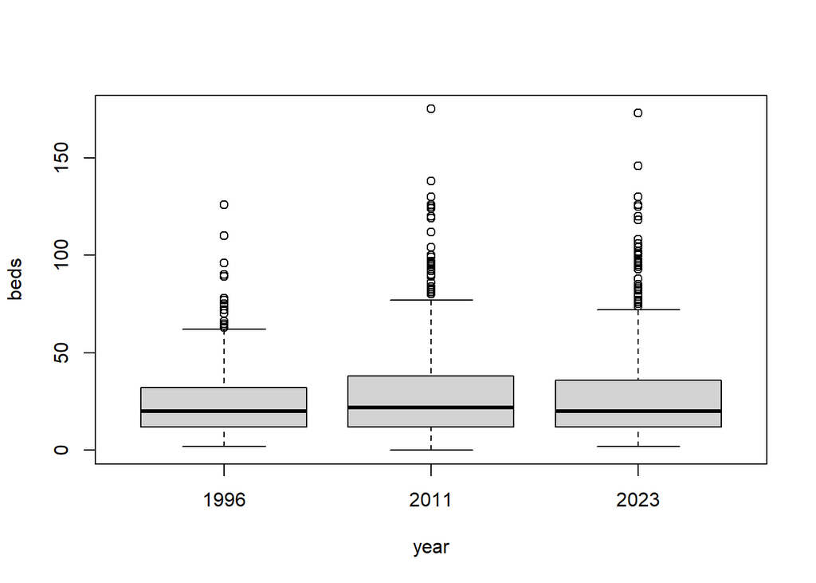

```r
all_nicu_geo$category <- as.factor(all_nicu_geo$year)

my_points_spatial <- st_as_sf(all_nicu_geo[grep("MAYO",all_nicu_geo$name),], coords = c('lon','lat'), crs = 4326)

boxplot(beds~year, data = all_nicu_geo)
```

```r
#counties <- tigris::counties(state = 27, cb = TRUE)
roads <- tigris::roads(state = 27, county = 109)
```

[output not shown]

[output cut: 186 more lines]

[output not shown]

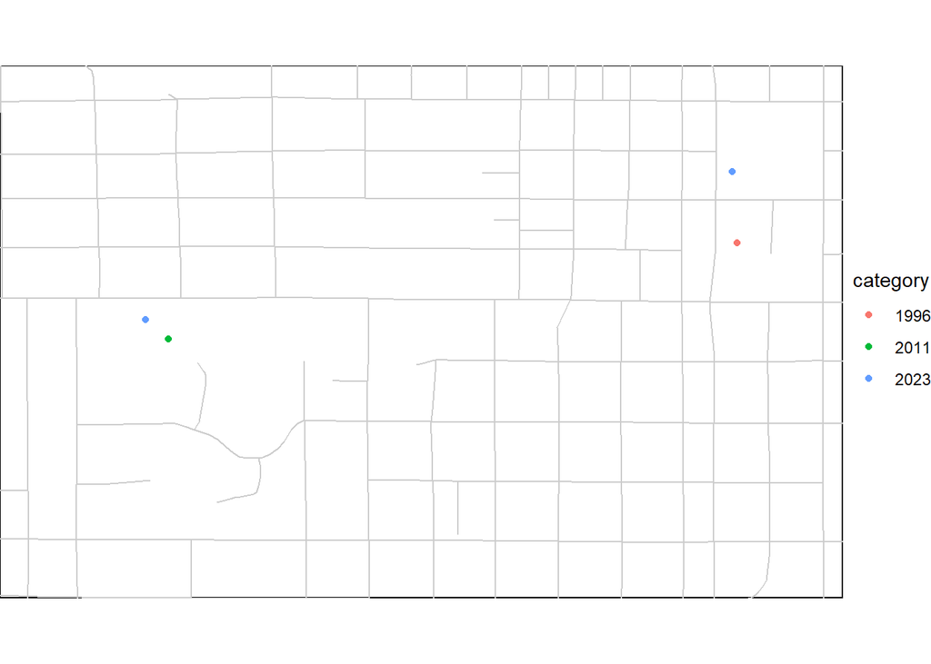

```r
#water <- tigris::area_water(state = 27, county = 109)


#  geom_sf(data = counties, fill = 'gray95', color = 'gray90') +
#  geom_sf(data = water, fill = 'white', color = NA)

p <- ggplot() +
  geom_sf(data = roads, color = 'gray80') +
  geom_sf(data = my_points_spatial, aes(color = category)) +
  scale_x_continuous(limits = c(-92.486, -92.464), expand = c(0,0)) +
  scale_y_continuous(limits = c(44.016, 44.026), expand = c(0,0)) +
  theme_void() +
  theme(panel.background = element_rect(fill = 'white'))
p
```

```r
all_nicu_geo <- st_as_sf(all_nicu_geo, coords = c("lon", "lat"), crs = 4326)

# Counties from tigris
#cnty <- counties(state = NULL)
# Fix invalid geometries
#cnty <- st_make_valid(cnty)

# States
#state_list <- states()

#temp <- list()
#k <- 1
#for (i in state_list$STUSPS){
#   temp[[k]] <- tracts(year = 2000, state = i)
#   k <- k + 1
#}
#result <- do.call(rbind.data.frame,temp)
#tract2000 <- st_make_valid(result)
#tract2000 <- st_transform(tract2000 , crs = 4326)

#all_nicu_tract2000 <- st_intersection(all_nicu_geo, tract2000)

#tract2010 <- tracts(year = 2010)
#tract2020 <- tracts(year = 2020)
```

Resources: Dartmouth Atlas of Neonatal Intensive Care [https://www.dartmouthatlas.org/Neonatal_Atlas_090419.pdf](https://urldefense.com/v3/__https://www.dartmouthatlas.org/Neonatal_Atlas_090419.pdf__;!!K-Hz7m0Vt54!ljZIEcQJaGpSIOiEm3QKgTGJey2bBh_m-m2WK18IG3jlDFL0UmvAO3R6k_eA8AhyWGKBF580qGg9_RGy$)

Opioid treatment: “We used the 2017 U.S. Census Bureau TIGER/Line shapefiles (Bureau, 2020) to estimate the driving distance from each census tract centroid to the 15 nearest opioid treatment providers using the Open Source Routing Machine ([http://project-osrm.org](https://urldefense.com/v3/__http://project-osrm.org__;!!K-Hz7m0Vt54!ljZIEcQJaGpSIOiEm3QKgTGJey2bBh_m-m2WK18IG3jlDFL0UmvAO3R6k_eA8AhyWGKBF580qJ8TL6GC$)) (Luxen and Vetter, 2011), which takes into account the speed limits of roads.”

“For each county in the U.S., we estimated the tract-level population- weighted mean, median, standard deviation, and interquartile range in driving time and driving distance to increasingly distant providers (i.e., the nearest, second nearest, etc.), stratifying the results by urban (large central metro, large fringe metro, medium metro, small metro) and rural (micropolitan, non-core) classification code. Each county (and tract within that county) was classified as either “urban” (i. e., large central metro, large fringe metro, medium metro, small metro) or “rural” (i.e., micropolitan, non-core) according to the 2013 Urban-Rural Classification Scheme for Counties developed by the U.S. National Center for Health Statistics (Ingram and Franco, 2014).”

“(2) using the US Census Bureau’s census tract-level center of population instead of geographic centroid of the tract. The raw data and replication code are available online at: [https://github](https://urldefense.com/v3/__https://github__;!!K-Hz7m0Vt54!ljZIEcQJaGpSIOiEm3QKgTGJey2bBh_m-m2WK18IG3jlDFL0UmvAO3R6k_eA8AhyWGKBF580qDvVRaLV$). com/mkiang/opioid_treatment_distance/.”